# malacoda simulations

# 5 Compare all methods

We compare the performance on the simulated assays by median performance across four metrics:

- AUC - The area under the receiver-operating curve. Higher is better.
- AUPR - The area under the precision-recall curve. Higher is better.
- spread at zero - The standard deviation of TS estimates of the truly nonfunctional variants. Lower is better.
- nonzero correlation - The correlation between the true TS values and the TS estimates. Higher is better.

The first two metrics quantify the binary classification properties of the various methods, while the latter two metrics quantify the accuracy of the TS estimates themselves. The latter two metrics can be visualized in terms of figure 3A from the paper, reproduced here:

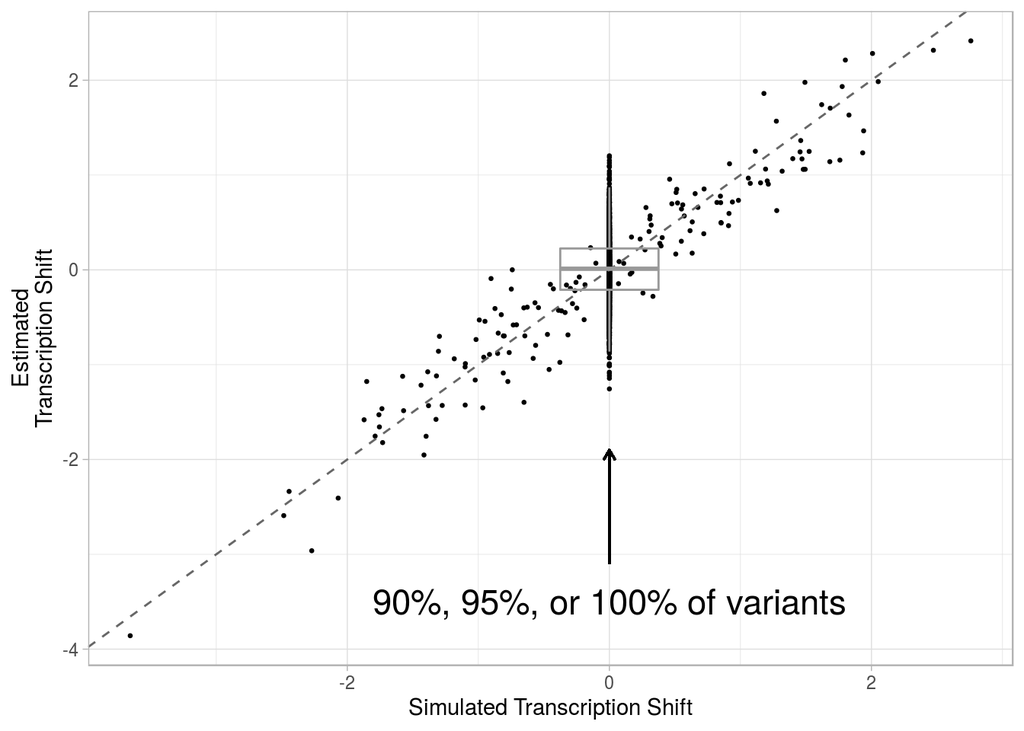

```r
sim_id = 'zwnxvebu'

load(paste0('/mnt/bigData2/andrew/MPRA/sim_mpra/many_sims/', sim_id, '.RData'))
load(paste0('/mnt/bigData2/andrew/MPRA/sim_mpra/many_sims_malacoda/', sim_id, '/analysis_res.RData'))

sysfonts::font_add(family = 'Arial',
                   regular = '~/my_fonts/arial.ttf',
                                     italic = '~/my_fonts/Arial Italic.ttf')

plot_data =  left_join(current_sim, analysis_res,
                       by = 'variant_id')

example_comparison_plot = plot_data %>%
  ggplot(aes(effect_size, ts_post_mean)) +
  geom_point(size = .5) +
  geom_abline(lty = 2,
              color = 'grey40') +
  geom_segment(aes(x = 0, xend = 0,
                   y = -3.1, yend = -1.9),
               arrow = arrow(length = unit(2, 'mm'))) +
  annotate('text',
           x = 0, y = -3.5, label = '90%, 95%, or 100% of variants',
           size = 6) +
  geom_boxplot(fill = rgb(0,0,0,0),
               data = plot_data %>% filter(effect_size == 0),
               outlier.shape = NA,
               color = 'grey60') +
  labs(x = 'Simulated Transcription Shift',
       y = 'Estimated\nTranscription Shift') +
  theme_light()

example_comparison_plot
```

The cluster of points located at x = 0 are truly non-functional variants. An ideal analysis would shrink their TS estimates to zero. Thus, the “spread at zero” defined above can be used to quantify the accuracy of estimates on non-functional variants. The “nonzero correlation” measures the accuracy of estimates for the complement set of variants. The points located off the vertical line at x = 0 are truly functional variants. A better model will produce estimates that correlate more highly with the true values for a higher “nonzero correlation”.

The code block below joins all of the performance metrics for each method and generates Figure 3 from the paper.

```r
load('/mnt/bigData2/andrew/MPRA/sim_mpra/many_sims/sim_grid.RData')
load('/home/andrew/dev_malacoda/outputs/mprascore/ms_performance.RData')
load('/mnt/bigData2/andrew/MPRA/sim_mpra/mpralm_sim_performance.RData')
load('/mnt/bigData2/andrew/MPRA/sim_mpra/t_performance.RData')
load('/home/andrew/dev_malacoda/outputs/malacoda_perf.RData')
load('/home/andrew/dev_malacoda/outputs/ma_perf.RData')
load('/home/andrew/dev_malacoda/outputs/qm_perf.RData')

malacoda_perf %<>%
  left_join(sim_grid, by = 'sim_id') %>%
  group_by(p_func, n_variants, n_bpa) %>%
  summarise(med_auc = median(auc),
            med_saz = median(spread_at_zero),
            med_nzc = median(nonzero_cor),
            med_aupr = median(aupr)) %>%
  ungroup %>%
  mutate(method = 'malacoda') %>%
  gather(metric, value, matches('med_'))

ms_performance %<>%
  unnest_legacy() %>%
  group_by(p_func, n_variants, n_bpa) %>%
  summarise(med_auc = median(auc),
            med_saz = median(spread_at_zero),
            med_nzc = median(nonzero_cor),
            med_aupr = median(aupr)) %>%
  ungroup %>%
  mutate(method = 'MPRAscore') %>%
  gather(metric, value, matches('med_'))

mpralm_sim_performance %<>%
  group_by(p_func, n_variants, n_bpa) %>%
  summarise(med_auc = median(auc),
            med_saz = median(`spread_at_0`),
            med_nzc = median(nonzero_cor),
            med_aupr = median(aupr)) %>%
  ungroup %>%
  mutate(method = 'mpralm') %>%
  gather(metric, value, matches('med_'))

t_perf %<>%
  group_by(p_func, n_variants, n_bpa) %>%
  summarise(med_auc = median(auc),
            med_saz = median(mean_saz),
            med_nzc = median(mean_nzc),
            med_aupr = median(aupr)) %>%
  ungroup %>%
  mutate(method = 't-test') %>%
  gather(metric, value, matches('med_'))

all_perf = bind_rows(malacoda_perf,
                     ms_performance,
                     mpralm_sim_performance,
                     t_perf,
                     ma_perf,
                     qm_perf)

save(all_perf,
     file = '/home/andrew/dev_malacoda/outputs/all_perf.RData')

color_map = c('malacoda' = '#aa0000',
              'mpralm' = '#4daf4a',
              't-test' = '#984ea3',
              'MPRAscore' = '#377eb8',
              'MPRAnalyze' = '#FF7F00',
              'QuASAR-MPRA' = '#F781BF')

sysfonts::font_add(family = 'Arial',
                   regular = '~/my_fonts/arial.ttf',
                                     italic = '~/my_fonts/Arial Italic.ttf')

all_perf_fig = all_perf %>%
  mutate(method = factor(method, levels = c('malacoda', 'MPRAnalyze', 'mpralm', 'QuASAR-MPRA', 't-test', 'MPRAscore'))) %>%
  filter(n_variants == 3000, p_func == .05, n_bpa == 10) %>%
  mutate(metric = str_replace_all(metric,
                                  c('med_auc' = 'median AUC',
                                    'med_saz' = 'median spread\nat zero',
                                    'med_nzc' = 'median nonzero\ncorrelation',
                                    'med_aupr' = 'median AUPR'))) %>%
  ggplot(aes(method, value, group = method)) +
  geom_col(aes(fill = method),
                        show.legend = FALSE) +
  scale_fill_manual(breaks = names(color_map),
                    values = color_map) +
  facet_grid(~metric) +
  labs(x = NULL) +
  theme_light(base_family = 'Arial') +
  theme(strip.text = element_text(color = 'black'),
        axis.text.x = element_text(angle = 45, hjust = 1),
        axis.title.y = element_blank(),
        text = element_text(family = 'Arial',
                            size = 40,
                            lineheight = .3))

ggsave(all_perf_fig,
      filename = '/home/andrew/dev_malacoda/outputs/figures/sim_comparison.png',
       dpi = 300,
      height = 3.5,
      units = 'in',
      width = 5.5)
```

The code block below generates the supplementary figures analogous to Figure 3 for the other grid points in the simulation. In cases where p_func = 0, the AUC, AUPR, and nonzero correlation values are not defined, so these panels are left blank.

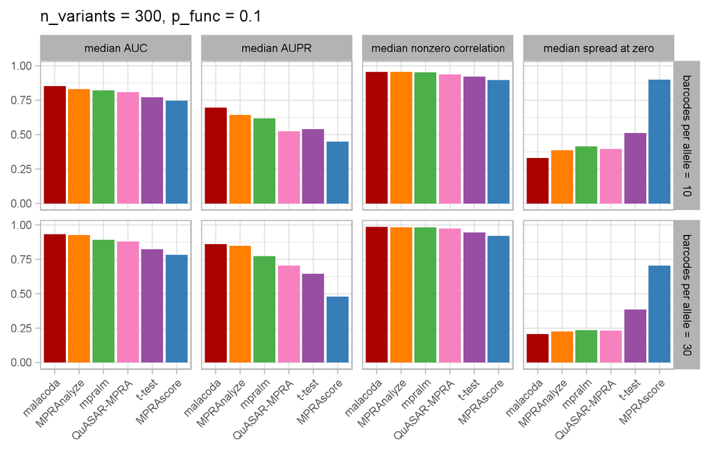

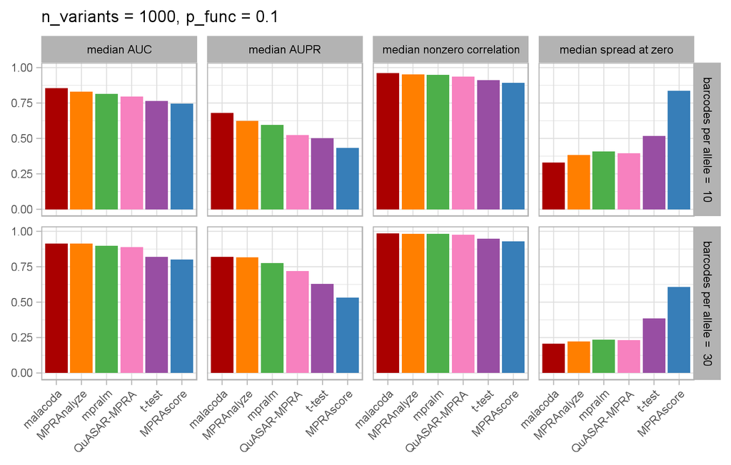

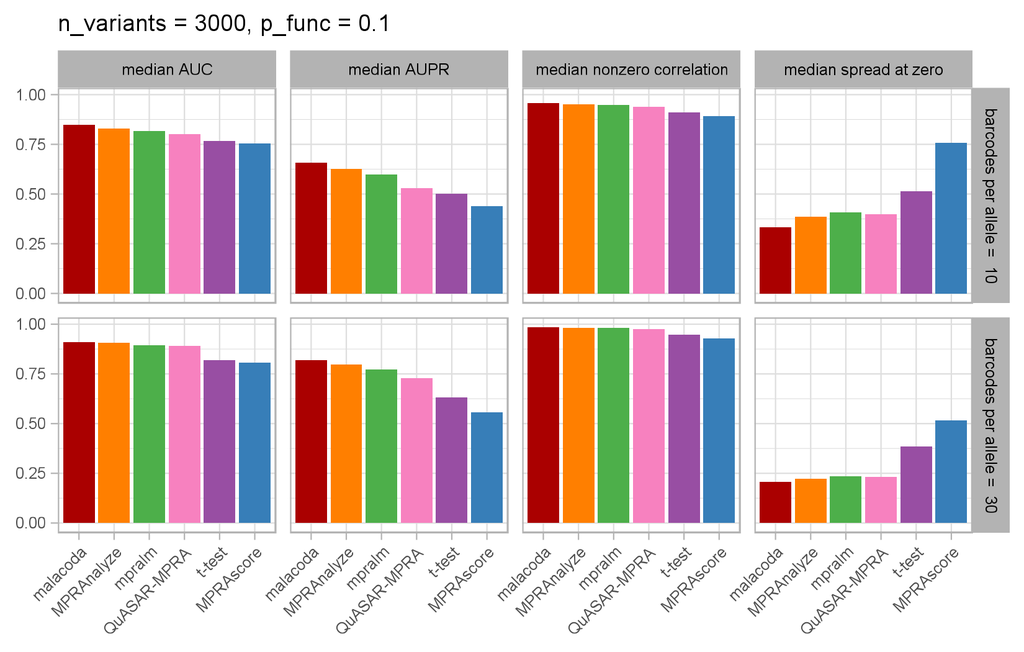

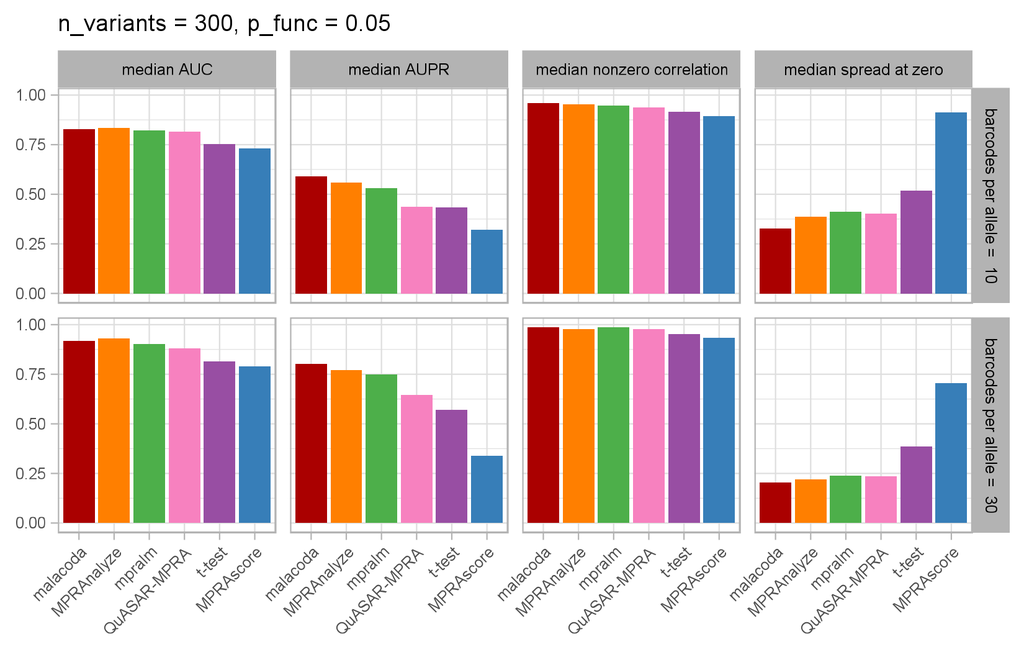

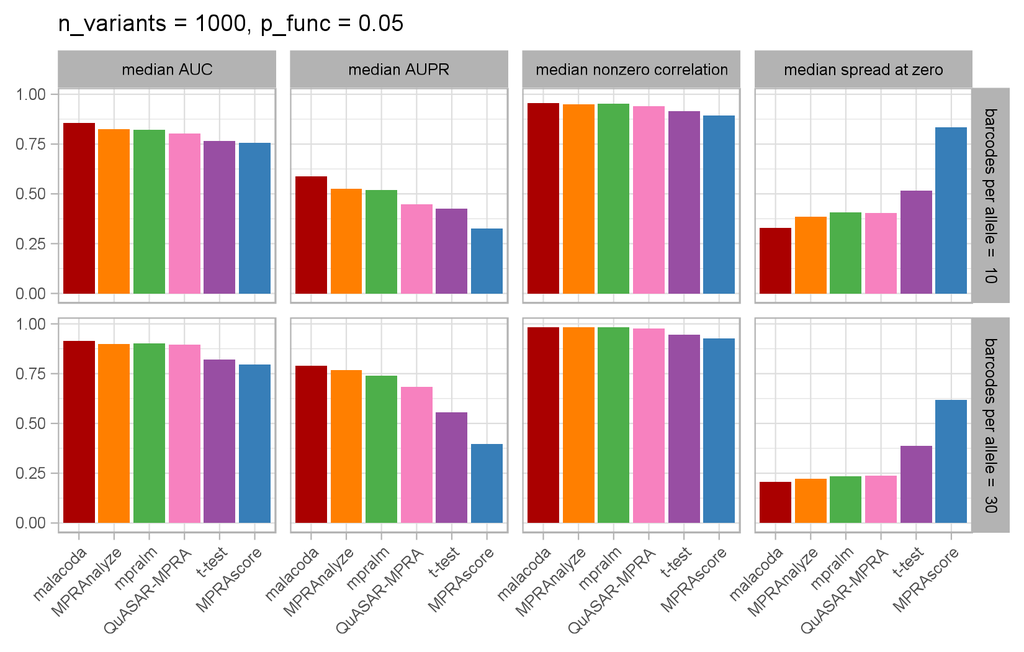

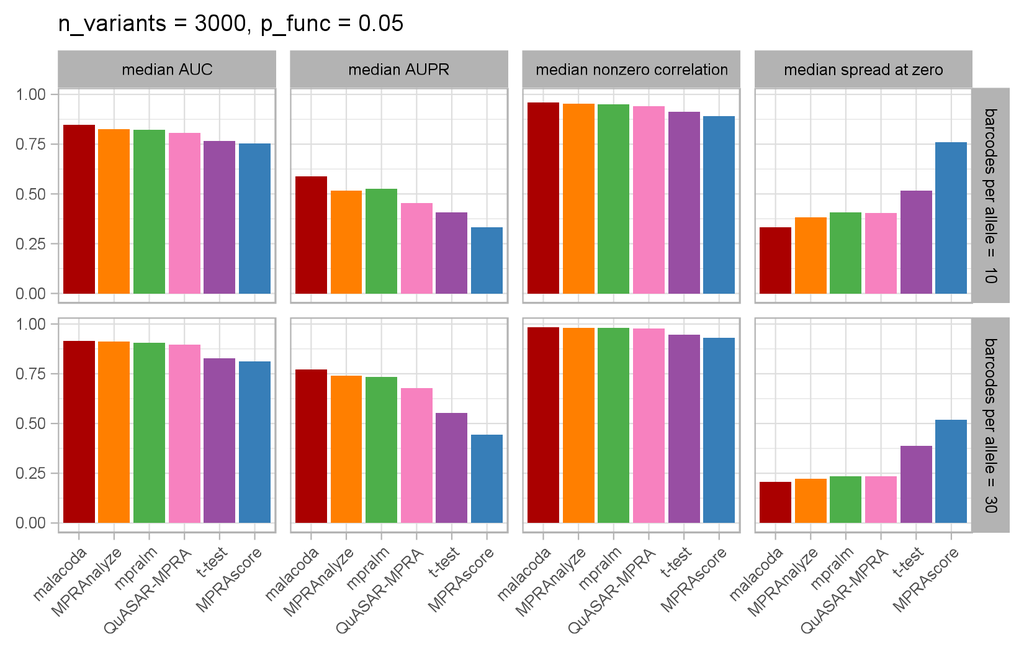

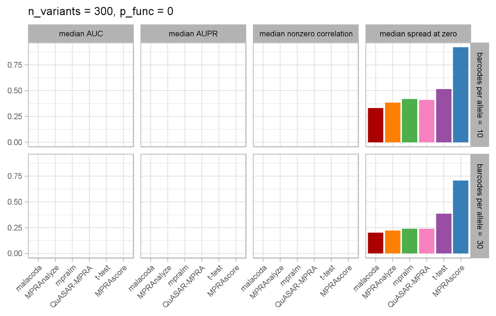

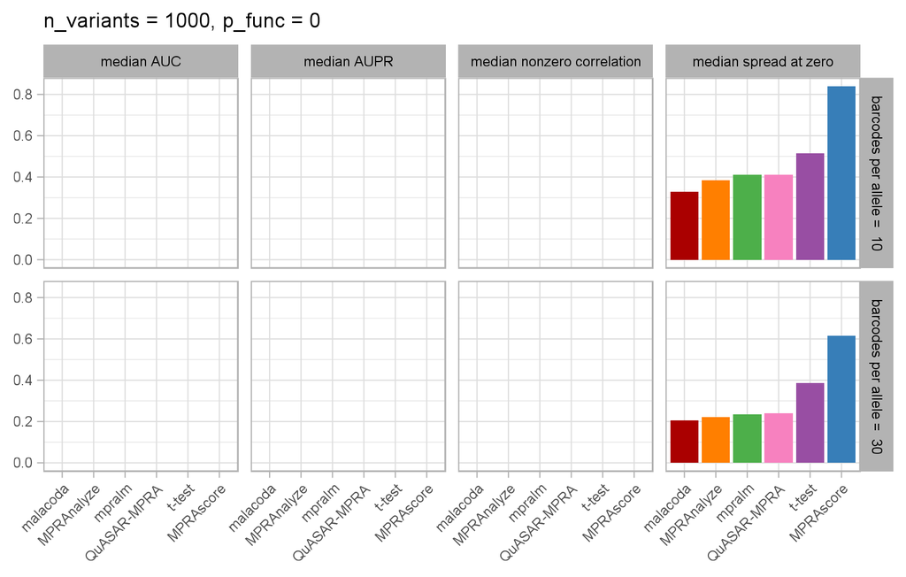

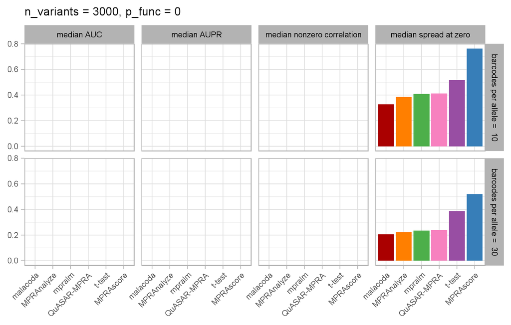

```r
load('/home/andrew/dev_malacoda/outputs/all_perf.RData')

library(magrittr)
library(tidyverse)

color_map = c('malacoda' = '#aa0000',
              'mpralm' = '#4daf4a',
              't-test' = '#984ea3',
              'MPRAscore' = '#377eb8',
              'MPRAnalyze' = '#FF7F00',
              'QuASAR-MPRA' = '#F781BF')

sysfonts::font_add(family = 'Arial',
                   regular = '~/my_fonts/arial.ttf',
                                     italic = '~/my_fonts/Arial Italic.ttf')

make_bar_plot = function(n_variants_plot, p_func_plot){

  b_plot = all_perf %>%
    mutate(method = factor(method, levels = c('malacoda', 'MPRAnalyze', 'mpralm', 'QuASAR-MPRA', 't-test', 'MPRAscore'))) %>%
    filter(n_variants_plot == n_variants, p_func == p_func_plot) %>%
    mutate(metric = str_replace_all(metric,
                                    c('med_auc' = 'median AUC',
                                      'med_saz' = 'median spread at zero',
                                      'med_nzc' = 'median nonzero correlation',
                                      'med_aupr' = 'median AUPR')),
           n_bpa = paste('barcodes per allele = ', n_bpa)) %>%
    ggplot(aes(method, value, group = method)) +
    geom_col(aes(fill = method),
             show.legend = FALSE) +
    scale_fill_manual(breaks = names(color_map),
                      values = color_map) +
    facet_grid(n_bpa~metric) +
    labs(x = NULL) +
    theme_light() +
    theme(strip.text = element_text(color = 'black'),
          axis.text.x = element_text(angle = 45, hjust = 1),
          axis.title.y = element_blank(),
          text = element_text(family = 'Arial',
                              size = 24, lineheight = .3)) +
    labs(title = paste0('n_variants = ', n_variants_plot, ', p_func = ', p_func_plot))

  ggsave(b_plot,
         filename = paste0('/home/andrew/dev_malacoda/outputs/figures/b_plot_', n_variants_plot, '_', p_func_plot, '.png'),
         height = 3.5,
         units = 'in',
         width = 5.5)
}

## Command to make the plots:
# all_perf %>% select(1:2) %>%
#   arrange(-p_func) %>%
#   unique %>%
#   {parallel::mcmapply(make_bar_plot,
#                      .$n_variants, .$p_func,
#                      mc.cores = 3)}

image_list = all_perf %>% select(1:2) %>%
  arrange(-p_func) %>%
  unique %$%
  map2_chr(n_variants, p_func,
       ~paste0('/home/andrew/dev_malacoda/outputs/figures/b_plot_', .x, '_', .y, '.png'))

knitr::include_graphics(image_list, auto_pdf = TRUE)
```

malacoda performs the best by each metric in all but a few cases where the differences are small and within the range of the simulation’s Monte Carlo error.

# 6 malacoda regularization

MPRA simulations also present an opportunity to demonstrate the regularizing effect of the prior used by malacoda. Using the data from an assay with 5% functional variants out of 3000 and 30 barcodes per allele, we can plot the (unregularized) t-test estimates against the regularized malacoda estimates:

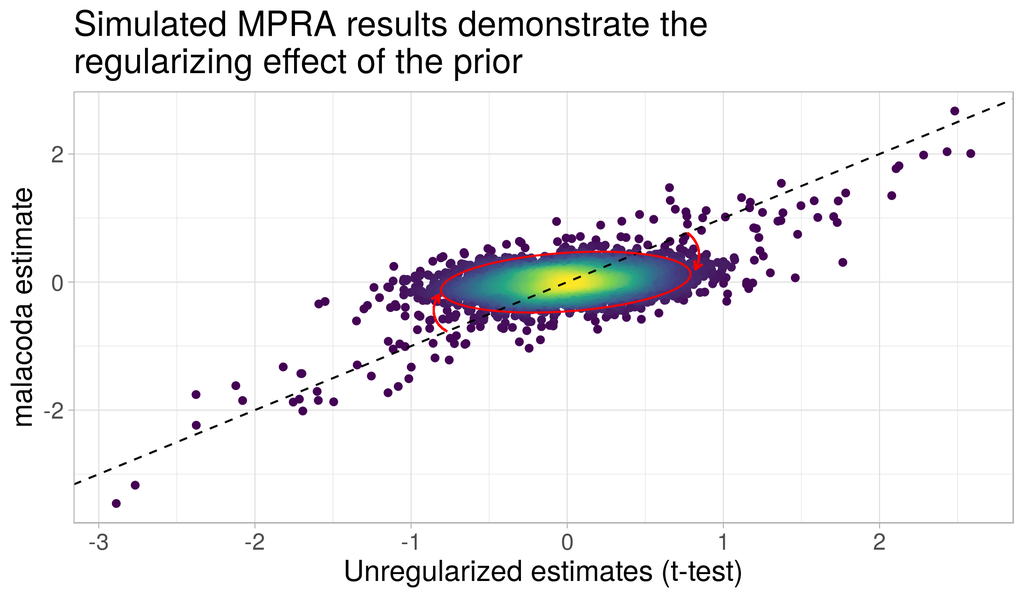

```r
library(tidyverse)
library(magrittr)
library(ghzutils)

load('/mnt/bigData2/andrew/MPRA/sim_mpra/many_sims/sim_grid.RData')
load('/mnt/bigData2/andrew/MPRA/sim_mpra/many_sims_t/dtsrpkio_test_df.RData')
load('/mnt/bigData2/andrew/MPRA/sim_mpra/many_sims_malacoda/dtsrpkio/analysis_res.RData')


plot_data = test_df %>%
  left_join(analysis_res, suffix = c('_t', '_malacoda'), by = 'variant_id') %>%
  add_local_density(ts_estimate, ts_post_mean)

reg_plot = plot_data %>%
  ggplot(aes(ts_estimate, ts_post_mean)) +
  geom_point(aes(color = local_density)) +
  geom_abline(lty = 2) +
  stat_ellipse(data = plot_data %>% filter(abs(ts_estimate) < 1), color = 'red') +
  geom_curve(aes(x = .77, xend = .82,
                 y = .77, yend = .2),
             curvature = -.4,
             color = 'red',
             arrow = arrow(length = unit(.02, 'npc'))) +
  geom_curve(aes(x = -.77, xend = -.82,
                 y = -.77, yend = -.2),
             curvature = -.5,
             color = 'red',
             arrow = arrow(length = unit(.02, 'npc'))) +
  theme_light() +
  scale_color_viridis_c(guide = FALSE) +
  labs(x = 'Unregularized estimates (t-test)',
       y = 'malacoda estimate',
       title = 'Simulated MPRA results demonstrate the\nregularizing effect of the prior') +
  theme(text = element_text(size = 15))
ggsave(reg_plot, filename = '~/dev_malacoda/outputs/regularization_plot.png')
```

Because the empirical prior concentrates probability mass around TS = 0, posterior estimates of TS are shrunken towards 0 as well. This is indicated by the less than 45° angle of the red ellipse, containing the majority of non-functional variants. If the malacoda model did not impose regularization, this ellipse would tend to align with dotted line on y=x. The uncommon cases of malacoda estimates more extreme than the unregularized t-test estimates are the result of different model structures producing different estimates.

Nonetheless, any binarization process will result in false positives. malacoda users can mitigate the risk of false positives by increasing the TS HDI threshold used in `fit_mpra_model()` to 99% (from 95%). Alternatively, the function `malacoda::increase_regularization()` can be used to manually increase the regularization used by malacoda by a set factor. Both of these measures come at the cost of an increased false negative rate.

# 7 Conclusion